# Assignment 4

Claudia Toto

2026-10-03

```r
library(readxl)
library(fpp2)
```

## Data

The dataset contains monthly retail sales observations.

```r
data_check <- read_excel(
  "MRTSSM44000USN.xlsx",
  sheet = "Monthly"
)

head(data_check)
```

```
## # A tibble: 6 × 2
##   observation_date    MRTSSM44000USN
##   <dttm>                       <dbl>
## 1 1992-01-01 00:00:00         126717
## 2 1992-02-01 00:00:00         127022
## 3 1992-03-01 00:00:00         137978
## 4 1992-04-01 00:00:00         142314
## 5 1992-05-01 00:00:00         147550
## 6 1992-06-01 00:00:00         146991
```

```r
names(data_check)
```

```
## [1] "observation_date" "MRTSSM44000USN"
```

```r
str(data_check)
```

```
## tibble [415 × 2] (S3: tbl_df/tbl/data.frame)
##  $ observation_date: POSIXct[1:415], format: "1992-01-01" "1992-02-01" ...
##  $ MRTSSM44000USN  : num [1:415] 126717 127022 137978 142314 147550 ...
```

```r
attributes(data_check)
```

[output not shown]

[output cut: 16 more lines]

## Time Series

```r
sales_ts <- ts(
  data_check$MRTSSM44000USN,
  start = c(1992, 1),
  frequency = 12
)

sales_ts
```

```
##         Jan    Feb    Mar    Apr    May    Jun    Jul    Aug    Sep    Oct
## 1992 126717 127022 137978 142314 147550 146991 147657 147901 143808 151260
## 1993 133217 130321 148430 153623 158325 157935 159382 159264 154669 159213
## 1994 141534 142096 168571 165664 170292 173036 168000 177283 170304 173559
## 1995 154048 150654 176579 171509 184842 186041 177637 188151 177734 179265
## 1996 163465 169234 186461 186280 199961 191144 191549 199008 184492 196530
## 1997 176396 173491 198366 193895 205961 199982 203254 206643 196212 204643
## 1998 182730 178930 202654 206879 215709 215167 212032 211123 203599 214737
## 1999 191953 194412 224556 221500 231696 231137 231446 234869 225224 227639
## 2000 208890 221662 247840 233673 251700 249293 238970 251694 238007 239482
## 2001 221577 218731 247585 243520 262673 254671 246061 260695 231126 259459
## 2002 225350 222775 251229 251463 265320 254456 260830 271526 240697 253801
## 2003 236653 227883 258435 259979 275037 265140 273249 278948 259303 267372
## 2004 247209 247809 281528 278111 289868 283390 288606 287769 276727 281014
## 2005 257652 259266 299818 295750 304842 310924 310812 314907 294215 295785
```

[output cut: 57 more lines]

```r
attributes(sales_ts)
```

```
## $tsp
## [1] 1992.0 2026.5   12.0
##
## $class
## [1] "ts"
```

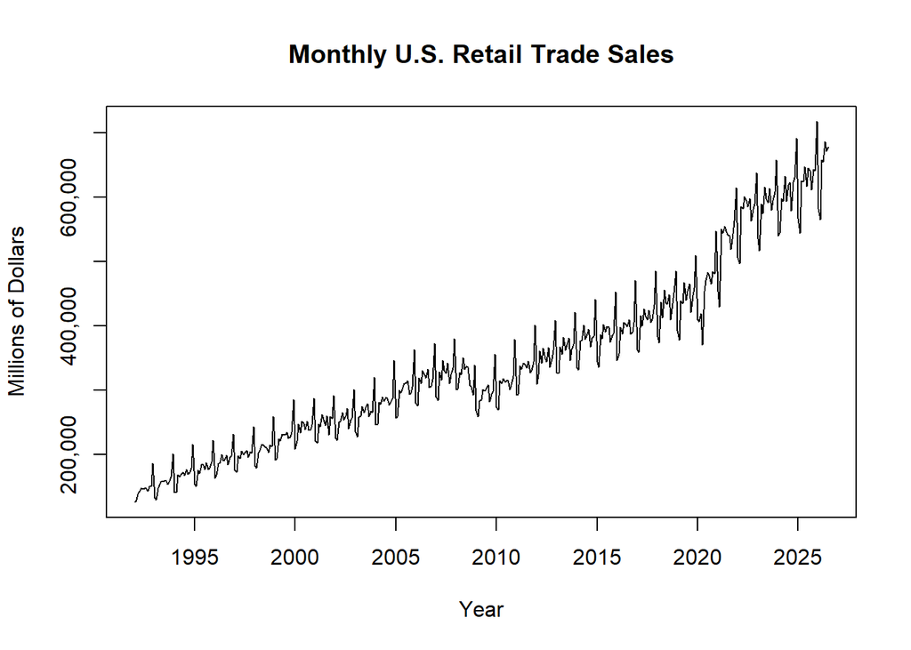

```r
## Time Series Plot
plot(sales_ts,
     main = "Monthly U.S. Retail Trade Sales",
     xlab = "Year",
     ylab = "Millions of Dollars",
     yaxt = "n")

axis(2,
     at = seq(100000, 700000, by = 100000),
     labels = format(seq(100000, 700000, by = 100000),
                     big.mark = ",",
                     scientific = FALSE))
```

#### The time series shows monthly U.S. retail sales over time. The series has a clear overall upward trend, indicating that retail sales generally increase over the years. The plot also shows recurring monthly fluctuations, suggesting the presence of seasonality. There is a noticeable decline around 2008–2009, followed by a recovery and continued growth. The variability also becomes larger as the level of sales increases.

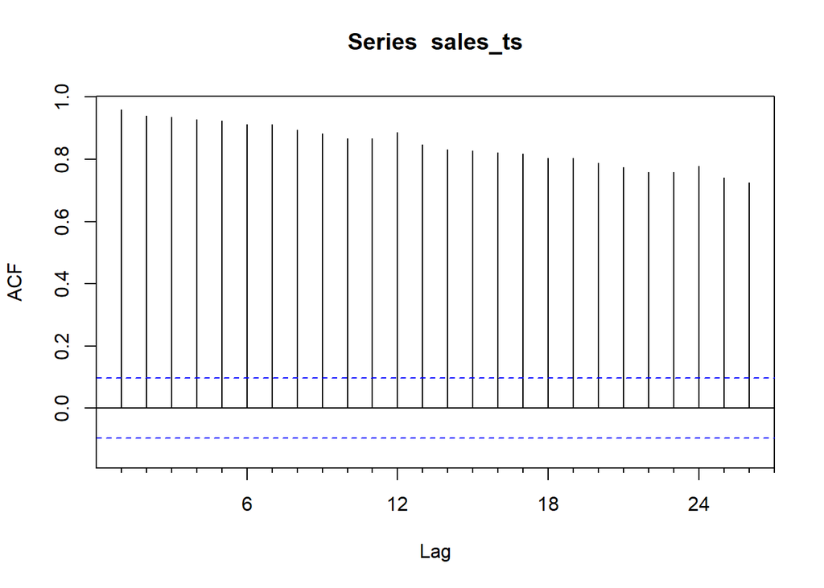

```r
Acf(sales_ts)
```

#### The ACF plot shows very high positive autocorrelation at the first several lags, with the autocorrelation decreasing slowly as the lag increases. This indicates that observations that are close together in time are strongly related to each other. The slow decline in the ACF is consistent with the strong upward trend and seasonal patterns observed in the time series. This suggests that the series is not stationary.

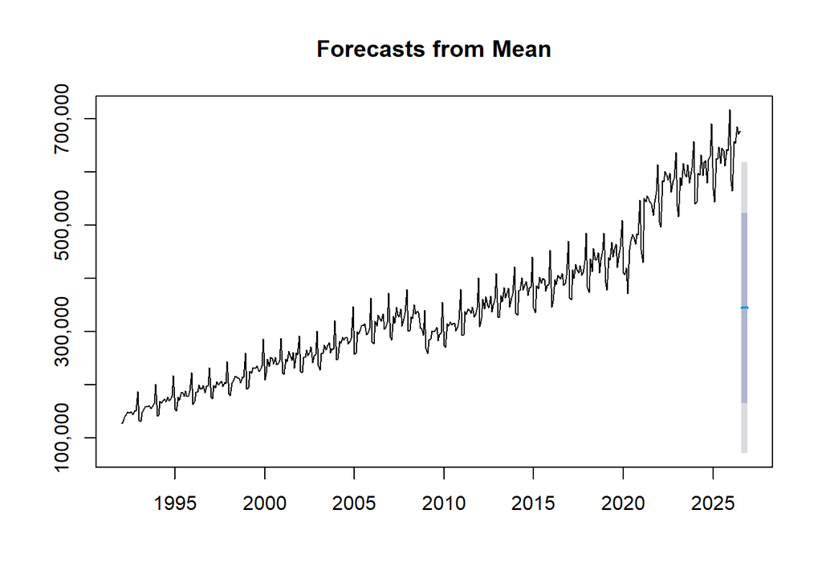

```r
# Take Mean of all available history
mean_forecast <- meanf(sales_ts, 5)

plot(mean_forecast,
     yaxt = "n")

axis(2,
     at = seq(100000, 700000, by = 100000),
     labels = format(seq(100000, 700000, by = 100000),
                     big.mark = ",",
                     scientific = FALSE))
```

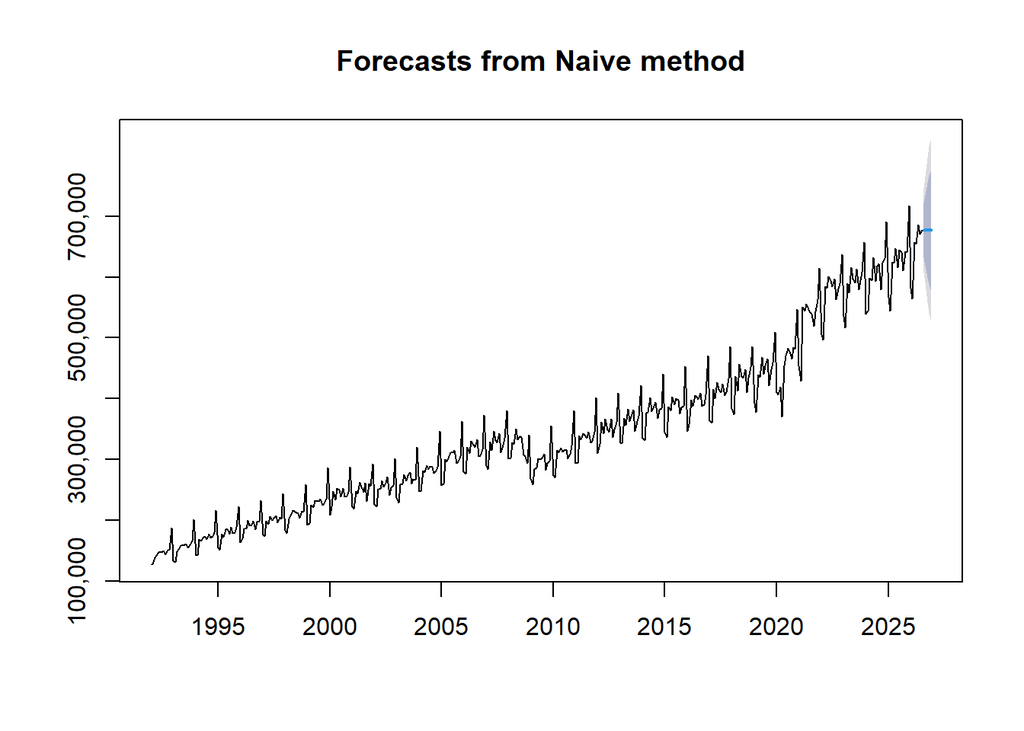

```r
# Naive Forecast

naive_forecast <- naive(sales_ts, 5)

plot(naive_forecast,
     yaxt = "n")

axis(2,
     at = seq(100000, 700000, by = 100000),
     labels = format(seq(100000, 700000, by = 100000),
                     big.mark = ",",
                     scientific = FALSE))
```

#### The Naive method uses the last observed value of the time series as the forecast for all future periods. In the plot, the forecasts remain approximately constant at the level of the most recent observation. The prediction intervals become wider as the forecast horizon increases, reflecting greater uncertainty. This method does not explicitly account for the long-term upward trend or seasonal pattern in the series.

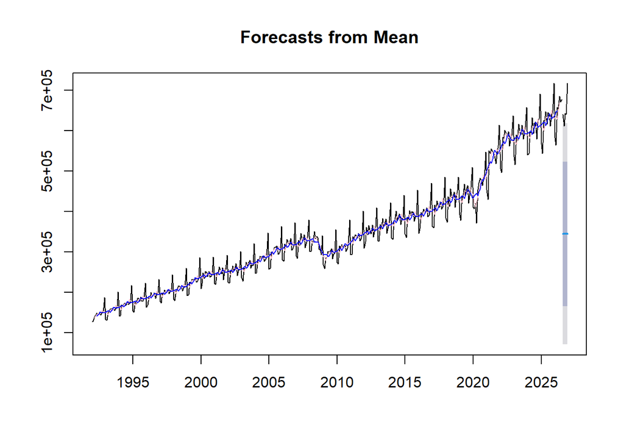

```r
# Seasonal Naive
snaive_forecast <- snaive(sales_ts, 5)

# Moving Averages
MA5_forecast <- ma(sales_ts, order = 5)
MA9_forecast <- ma(sales_ts, order = 9)

# Plot all models in a single chart
plot(mean_forecast)

lines(snaive_forecast$mean, col = "black")
lines(MA5_forecast, col = "pink")
lines(MA9_forecast, col = "blue")
```

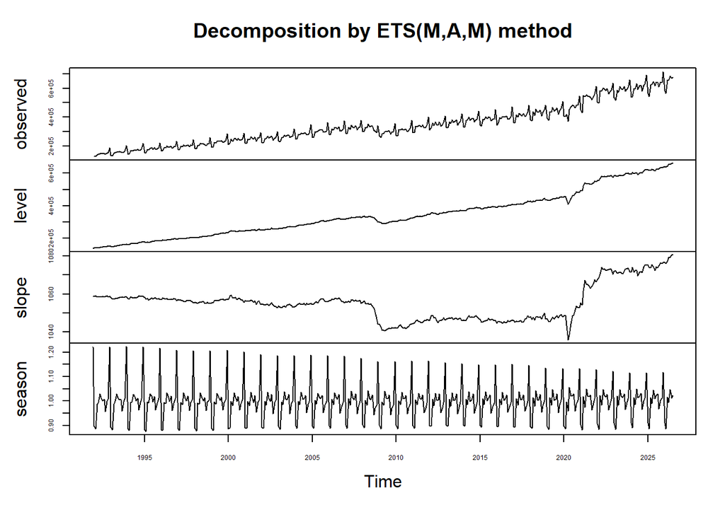

```r
# Decomposition
ets_forecast <- ets(sales_ts)
plot(ets_forecast,
     cex.axis = 0.55)
```

```r
attributes(ets_forecast)
```

```
## $names
##  [1] "loglik"     "aic"        "bic"        "aicc"       "mse"
##  [6] "amse"       "fit"        "residuals"  "fitted"     "states"
## [11] "par"        "m"          "method"     "series"     "components"
## [16] "call"       "initstate"  "sigma2"     "x"
##
## $class
## [1] "fc_model" "ets"
```

```r
ets_forecast$mse
```

```
## [1] 90224969
```

##### The ETS decomposition separates the time series into observed, level, slope, and seasonal components. The observed series shows a clear long-term upward trend with regular monthly fluctuations. The level component increases over time, with noticeable changes around 2009 and 2020. The slope component shows changes in the growth rate, including a decline around 2009 and a sharp increase after 2020. The seasonal component shows a consistent monthly pattern throughout the series, indicating strong recurring seasonality.

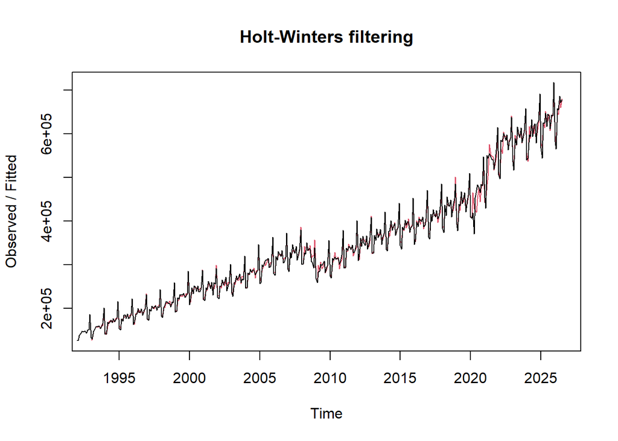

```r
# Holt-Winters
HW_model <- HoltWinters(sales_ts)
plot(HW_model)
```

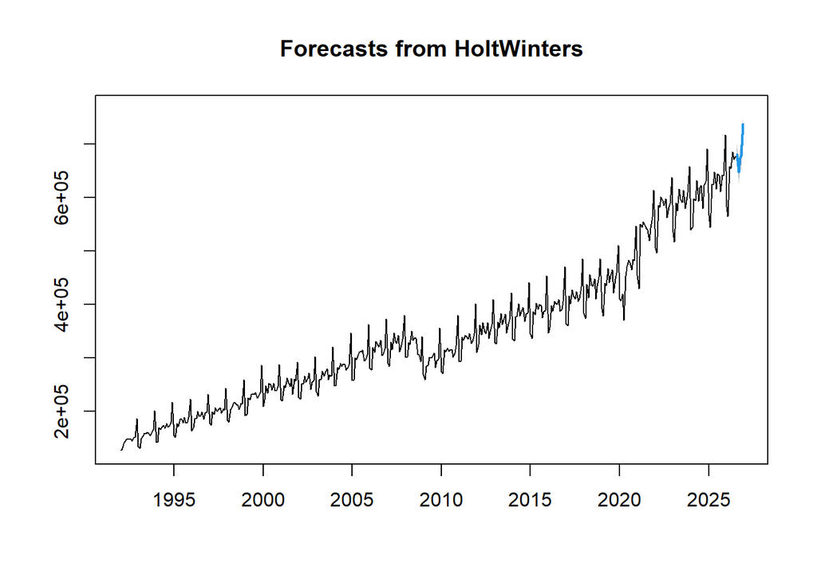

```r
# Holt-Winters forecast
HW_forecast <- forecast(HW_model, h = 5)
plot(HW_forecast)
```

```r
HW_forecast$mean
```

```
##           Aug      Sep      Oct      Nov      Dec
## 2026 680211.3 647194.3 674096.6 678172.2 737316.4
```

```r
# Simple Exponential Smoothing
SSE_Simple <- HoltWinters(sales_ts)
attributes(SSE_Simple)
```

```
## $names
## [1] "fitted"       "x"            "alpha"        "beta"         "gamma"
## [6] "coefficients" "seasonal"     "SSE"          "call"
##
## $class
## [1] "HoltWinters"
```

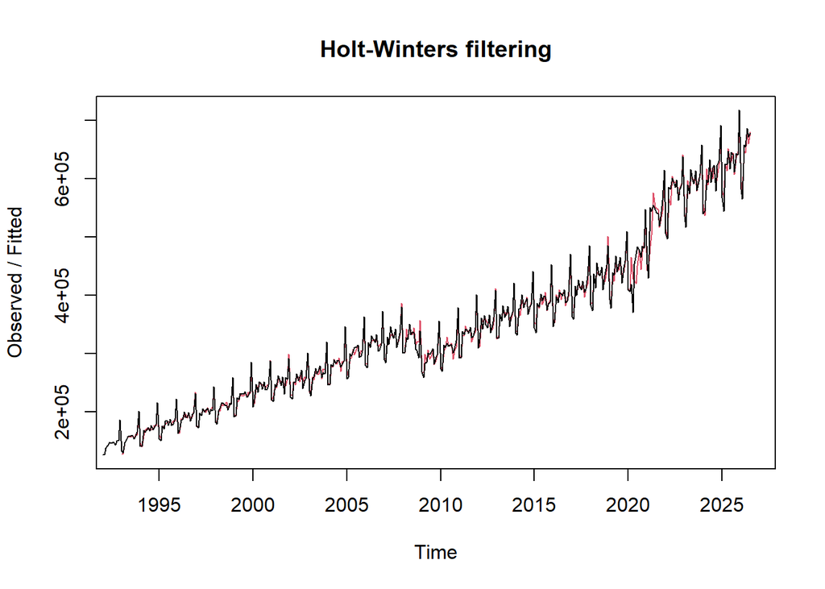

```r
plot(SSE_Simple)
```

```r
SSE_Simple$SSE
```

```
## [1] 38836600216
```

```r
head(SSE_Simple$fitted)
```

```
##              xhat    level    trend      season
## Jan 1993 128157.1 145200.9 882.8511 -17926.7292
## Feb 1993 127826.5 148706.9 904.3570 -21784.7292
## Mar 1993 147217.7 150904.4 914.9590  -4601.7292
## Apr 1993 153175.3 152447.9 920.1118   -192.6458
## May 1993 158083.3 153600.1 922.0144   3561.2708
## Jun 1993 157513.3 154647.3 923.0415   1942.8958
```

#### The black line represents the observed values, while the red line represents the fitted values from the Holt-Winters model. The red line generally follows the black line, although there are larger differences during periods with sharp increases or decreases. This indicates that the model captures the general pattern of the series but does not perfectly capture all short-term fluctuations.

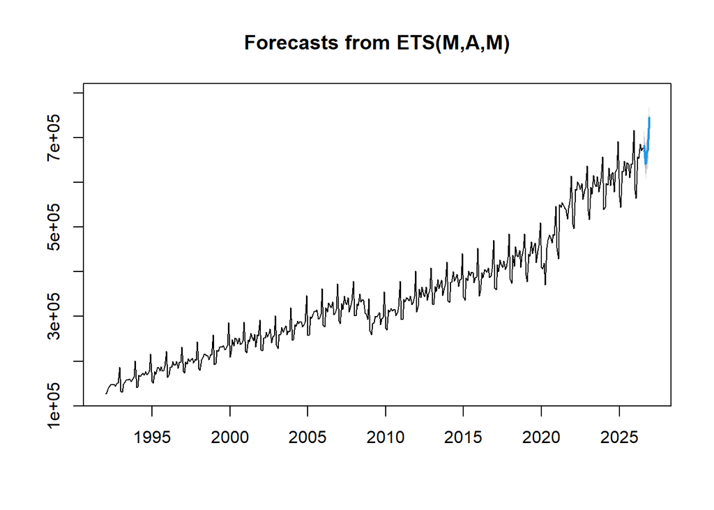

```r
#Forecast ETS
forecast_ets <- forecast.ets(ets_forecast, h = 5)
plot(forecast_ets)
```

```r
forecast_ets$mean
```

```
##           Aug      Sep      Oct      Nov      Dec
## 2026 682031.5 641481.4 666619.5 672815.5 745327.9
```

##### The ETS model was used to forecast the next five periods of the monthly U.S. retail trade sales series. The forecast is based on the level, trend, and seasonal patterns identified by the model. The black line represents the historical observations, while the blue line represents the forecast for the next five periods. The shaded area represents the prediction intervals and shows the uncertainty associated with the forecasts. The forecast continues the general pattern identified by the ETS model, while the prediction intervals become wider as the forecast horizon increases.

# Plot all models in a single chart

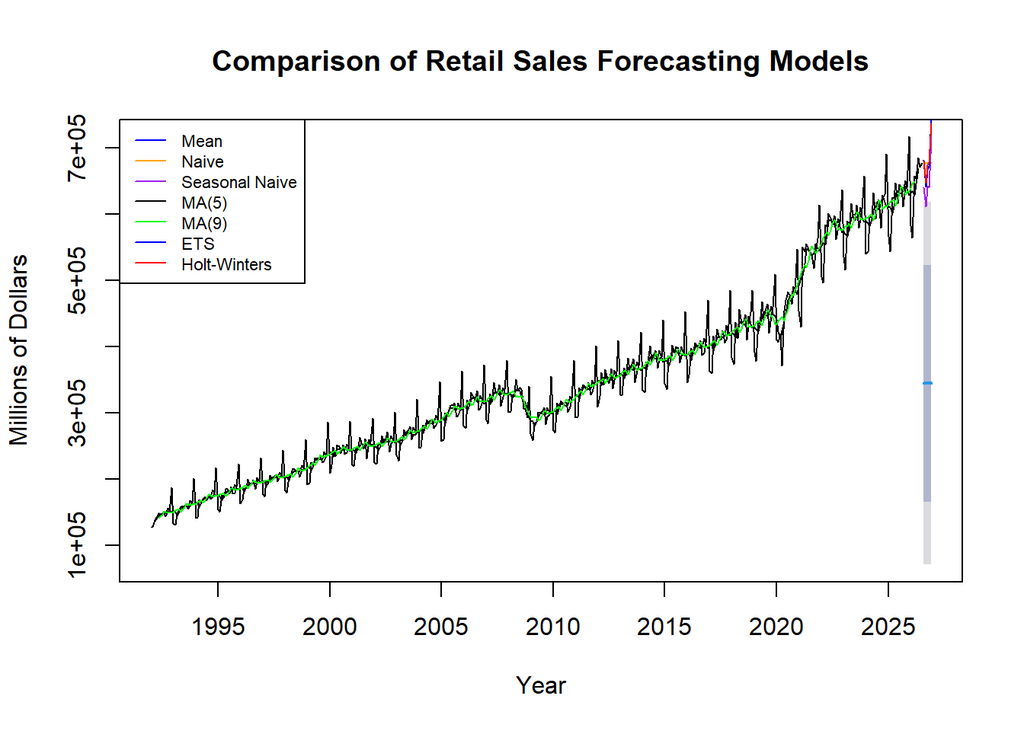

```r
# Plot all models in a single chart

# Naive Forecast
naive_forecast <- naive(sales_ts, 5)

# Seasonal Naive
snaive_forecast <- snaive(sales_ts, 5)

# Moving Averages
MA5_forecast <- ma(sales_ts, order = 5)
MA9_forecast <- ma(sales_ts, order = 9)

# ETS
ets_forecast <- ets(sales_ts)
forecast_ets <- forecast(ets_forecast, h = 5)

# Holt-Winters
HW_model <- HoltWinters(sales_ts)
HW_forecast <- forecast(HW_model, h = 5)

# Plot
plot(mean_forecast,
     main = "Comparison of Retail Sales Forecasting Models",
     xlab = "Year",
     ylab = "Millions of Dollars")

lines(naive_forecast$mean, col = "orange")
lines(snaive_forecast$mean, col = "purple")
lines(MA5_forecast, col = "black")
lines(MA9_forecast, col = "green")
lines(forecast_ets$mean, col = "blue")
lines(HW_forecast$mean, col = "red")

# Legend
legend("topleft",
       legend = c("Mean",
                  "Naive",
                  "Seasonal Naive",
                  "MA(5)",
                  "MA(9)",
                  "ETS",
                  "Holt-Winters"),
       col = c("blue",
               "orange",
               "purple",
               "black",
               "green",
               "blue",
               "red"),
       lty = 1,
       cex = 0.7)
```

# Forecast Accuracy

```r
accuracy(mean_forecast)
```

```
##                         ME     RMSE    MAE      MPE     MAPE     MASE      ACF1
## Training set -2.219236e-11 138921.6 111596 -17.9149 38.61924 6.294022 0.9584386
```

```r
accuracy(naive_forecast)
```

```
##                    ME    RMSE      MAE        MPE     MAPE     MASE       ACF1
## Training set 1329.787 35014.5 23308.22 -0.1222404 6.997985 1.314585 -0.3560073
```

```r
accuracy(snaive_forecast)
```

```
##                    ME     RMSE      MAE      MPE     MAPE MASE      ACF1
## Training set 14857.93 24036.96 17730.48 4.222057 5.156751    1 0.7817155
```

```r
accuracy(forecast_ets)
```

```
##                    ME     RMSE      MAE         MPE    MAPE      MASE
## Training set 327.9512 9498.682 6042.238 -0.01137703 1.72809 0.3407826
##                    ACF1
## Training set 0.09176803
```

```r
accuracy(HW_forecast)
```

```
##                    ME     RMSE      MAE      MPE     MAPE      MASE       ACF1
## Training set 503.4102 9816.758 6549.878 0.028063 1.873264 0.3694135 0.07640973
```

## Compare MAPE values

```r
MAPE_comparison <- data.frame(
  Model = c("Mean", "Naive", "Seasonal Naive", "ETS", "Holt-Winters"),
  MAPE = c(
    accuracy(mean_forecast)[,"MAPE"],
    accuracy(naive_forecast)[,"MAPE"],
    accuracy(snaive_forecast)[,"MAPE"],
    accuracy(forecast_ets)[,"MAPE"],
    accuracy(HW_forecast)[,"MAPE"]
  )
)

MAPE_comparison
```

```
##            Model      MAPE
## 1           Mean 38.619242
## 2          Naive  6.997985
## 3 Seasonal Naive  5.156751
## 4            ETS  1.728090
## 5   Holt-Winters  1.873264
```

#### Accuracy Comparison

##### I selected MAPE (Mean Absolute Percentage Error) as the accuracy measure because it expresses the forecast error as a percentage. The Mean model has a MAPE of 38.62%, the Naive model has 7.00%, the Seasonal Naive model has 5.16%, the ETS model has 1.73%, and the Holt-Winters model has 1.87%. Based on the MAPE comparison, the ETS model has the lowest forecast error among the models evaluated. Based on the accuracy comparison, ETS is the best-performing model according to MAPE because it has the lowest MAPE value (1.73%).